# HPP: COVID-19. Modelando desfechos

Ana Paula Pacheco, Carolina Prando e [Henrique Laureano](https://henriquelaureano.github.io/)

Last modification on* 2022-09-29 08:41:58

> Toda a modelagem é feita via regressão logística (um modelo linear generalizado com resposta binomial e função de ligação logit).

> O critério de seleção do modelo é o AIC (*Akaike Information Criteria*).

# Internamento

> 1028 pacientes, dos quais 204 foram internados.

> Todas as variáveis/características listadas abaixo foram inseridas num modelo para verificar quais são estatísticamente relevantes (significativas) para distinguir/separar os pacientes em internados e não-internados. Uma outra maneira de pensar é: verificar quais variáveis diferem significativamente entre seus níveis (sim ou não; presença ou não, por exemplo) ou com a mudança de magnitude (na caso das variáveis numéricas, como a idade por exemplo).

> As variáveis em negrito são aquelas que se mostraram significativas para o desfecho internamento. Ou seja, aquelas em negrito diferem entre pacientes internados e não-internados, e consequentemente podem ajudar/ajudam a categorizar os pacientes em termos desse desfecho.

| vars_int |
| --- |
| CARGA VIRAL |
| Sexo |
| IDADE |
| QUANTAS COMORBIDADES |
| Tempo inicio sintomas |
| FEBRE |
| CORIZA |
| DIARREIA |
| VOMITO |
| ODINOFAGIA |
| TOSSE |
| CEFALEIA |
| DIF RESP |
| ANOSMIA |
| MIALGIA |
| AGEUSIA |
| NAUSEAS |
| DOR ABD |
| CONVULSÃO |
| TAQUICARDIA |
| RASH/EXANTEMA |
| INAPETENCIA |
| OBST / CONGESTÃO NASAL |
| ESPIRROS |
| OUTROS |
| Neurológico |
| Renal/Urinário |
| Respiratório |
| Onco-Hemato |
| Endócrino |
| Cardiovascular |
| Sd Genética |
| Imunológico |
| número_de_sintomas |

> Abaixo listamos apenas as variáveis significativas, junto de duas métricas. A *deviance* é uma medida do tipo “quanto maior, mais significativa”. A outra medida é o valor-p.

> Em vermelho temos as variáveis significativas ao nível de 5% (valor-p $\leq$ 0.05) e em amarelo as variáveis com 0.05 < valor-p < 0.10.

> Algumas variáveis podem até não ter valor-p significativo, mas um modelo com a sua presença se mostrou melhor (em termos de AIC) do que um modelo sem ela.

|  | Deviance | Pr(>Chi) |
| --- | --- | --- |
| `CARGA VIRAL` | 41.718245 | 0.000000005 |
| Sexo | 5.577217 | 0.018195613 |
| IDADE | 3.336653 | 0.067752277 |
| `QUANTAS COMORBIDADES` | 150.217067 | 0.000000000 |
| `Tempo inicio sintomas` | 24.196996 | 0.000000870 |
| DIARREIA | 2.337383 | 0.126301593 |
| VOMITO | 7.129964 | 0.007580626 |
| ODINOFAGIA | 15.364616 | 0.000088633 |
| CEFALEIA | 4.969367 | 0.025800092 |
| `DIF RESP` | 88.638474 | 0.000000000 |
| AGEUSIA | 2.169359 | 0.140784890 |
| NAUSEAS | 2.569918 | 0.108913363 |
| `DOR ABD` | 13.873348 | 0.000195552 |
| CONVULSÃO | 23.807949 | 0.000001064 |
| TAQUICARDIA | 14.070114 | 0.000176120 |
| `RASH/EXANTEMA` | 4.185164 | 0.040779277 |
| Neurológico | 9.865721 | 0.001683867 |
| `Renal/Urinário` | 10.211839 | 0.001395420 |
| `Onco-Hemato` | 9.632245 | 0.001911907 |
| Endócrino | 6.281105 | 0.012203202 |
| `Sd Genética` | 4.657220 | 0.030923227 |

> A seguir desdobramos cada variável.

> O intercepto corresponde ao nível de referência, i.e. um paciente sem as variáveis dicotômicas (duas possibilidades: sim ou não) e com carga viral baixa, sexo feminino, idade média (6.889), número médio de comorbidades (0.244) e de tempo do início dos sintomas (2.228).

> Para cada nível de cada variável temos a sua estimativa (sem interpretação prática direta, mas que pode ser pensada como: se positiva, aumenta a probabilidade do desfecho. Se negativa, a probabilidade de desfecho diminuí). O seu erro padrão (incerteza associada a estimativa), a sua razão de chance, um intervalo de 95% de confiança para a razão de chance, e finalmente, o valor-p.

> A razão de chance é sempre em relação a algo, mais especificamente, ao intercepto/paciente do nível de referência. Por exemplo, um paciente com convulsão tem uma chance 68 vezes maior do desfecho (internação) do que um paciente sem convulsão (com todas as demais variáveis/condições do nível de referência fixas). Razões de chance menores que 1 tem o significado contrário. Por exemplo, carga viral média tem uma razão de chances de 0.28 comparado ao nível de referência (um paciente com carga viral baixa). Ou seja, sua chance de interrnação é 3.571 (1/0.28) vezes menor.

|  | Estimate | Standard error | Odds ratio | OR 2.5% CI | OR 97.5% CI | P-value |
| --- | --- | --- | --- | --- | --- | --- |
| (Intercept) | -2.241565698 | 0.34938534 | 0.1062920 | 0.05243007 | 0.2068660 | 0.0000000001 |
| `CARGA VIRAL`Média | -1.264424166 | 0.37020134 | 0.2824019 | 0.13475464 | 0.5780106 | 0.0006366409 |
| `CARGA VIRAL`Alta | -0.904258552 | 0.31442950 | 0.4048419 | 0.21879294 | 0.7530662 | 0.0040291491 |
| `CARGA VIRAL`NI | 0.008737126 | 0.32644218 | 1.0087754 | 0.53297001 | 1.9226893 | 0.9786474108 |
| SexoMasculino | 0.504424627 | 0.22844196 | 1.6560324 | 1.06353878 | 2.6094044 | 0.0272367116 |
| IDADE | -0.075960860 | 0.02518551 | 0.9268525 | 0.88120428 | 0.9728328 | 0.0025608768 |
| `QUANTAS COMORBIDADES` | 0.929114227 | 0.18942867 | 2.5322652 | 1.76076804 | 3.7076134 | 0.0000009351 |
| `Tempo inicio sintomas` | 0.121826345 | 0.03481110 | 1.1295579 | 1.05360727 | 1.2112713 | 0.0004658856 |
| DIARREIA | 0.493936392 | 0.29161993 | 1.6387543 | 0.91459961 | 2.8775119 | 0.0903094551 |
| VOMITO | 0.573002166 | 0.31745238 | 1.7735837 | 0.94128316 | 3.2762124 | 0.0710743763 |
| ODINOFAGIA | -1.126421402 | 0.42719640 | 0.3241913 | 0.13259540 | 0.7157721 | 0.0083697974 |
| CEFALEIA | -0.637306755 | 0.36971803 | 0.5287145 | 0.24800123 | 1.0634220 | 0.0847503975 |
| `DIF RESP` | 2.496417032 | 0.29099721 | 12.1389226 | 6.92222514 | 21.7220155 | 0.0000000000 |
| AGEUSIA | 1.147034175 | 0.72636032 | 3.1488401 | 0.68378468 | 12.0038630 | 0.1143009366 |
| NAUSEAS | 0.895583764 | 0.51194684 | 2.4487649 | 0.85852164 | 6.4448116 | 0.0802273106 |
| `DOR ABD` | 1.369418043 | 0.37922751 | 3.9330612 | 1.84516372 | 8.2072520 | 0.0003049334 |
| CONVULSÃO | 4.223900784 | 1.21807497 | 68.2993865 | 9.23842378 | 1532.1735984 | 0.0005249615 |
| TAQUICARDIA | 3.241531231 | 0.94750692 | 25.5728497 | 4.30495651 | 207.9155953 | 0.0006236469 |
| `RASH/EXANTEMA` | 1.496302561 | 0.80898161 | 4.4651489 | 0.87398812 | 22.6440730 | 0.0643694073 |
| Neurológico | 1.428886826 | 0.41994349 | 4.1740502 | 1.82584995 | 9.5286297 | 0.0006675542 |
| `Renal/Urinário` | 3.139795786 | 0.93859235 | 23.0991492 | 3.89907072 | 169.0432126 | 0.0008221800 |
| `Onco-Hemato` | 2.488581115 | 0.81103604 | 12.0441747 | 2.60596475 | 67.2005198 | 0.0021521000 |
| Endócrino | 2.105113743 | 0.85129793 | 8.2080366 | 1.68229074 | 48.8769728 | 0.0134048466 |
| `Sd Genética` | 1.447973424 | 0.69296433 | 4.2544837 | 1.13920752 | 17.8238375 | 0.0366595635 |

> E aqui apresentamos graficamente as variáveis mais importantes para cada nível do desfecho de interesse. Para as variáveis categóricas (Carga Viral e Sexo) apresentamos os efeitos médios, sendo assim capazes de separar seus efeitos do nível de referência definido acima. A cor indica o valor-p correspondente.

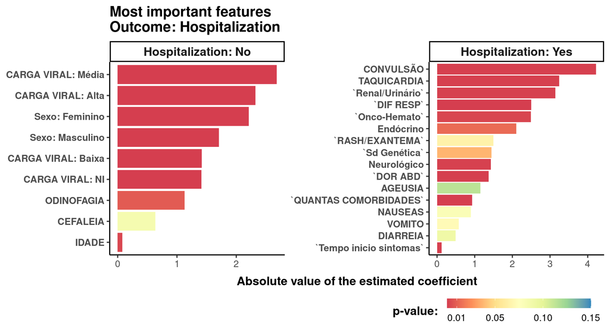

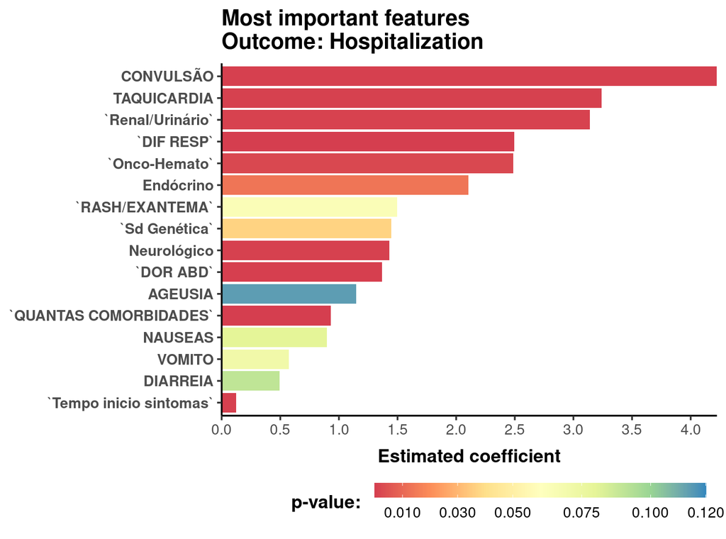

# UTI

> 204 pacientes internados, dos quais 60 foram para UTI.

> Em negrito, as variáveis significativas.

| vars_uti |
| --- |
| CARGA VIRAL |
| Sexo |
| IDADE |
| QUANTAS COMORBIDADES |
| Tempo inicio sintomas |
| FEBRE |
| CORIZA |
| DIARREIA |
| VOMITO |
| TOSSE |
| CEFALEIA |
| DIF RESP |
| MIALGIA |
| NAUSEAS |
| DOR ABD |
| CONVULSÃO |
| RASH/EXANTEMA |
| INAPETENCIA |
| ESPIRROS |
| OUTROS |
| Neurológico |
| Renal/Urinário |
| Respiratório |
| Onco-Hemato |
| Endócrino |
| Cardiovascular |
| Sd Genética |
| Imunológico |
| número_de_sintomas |
| UTI |

> As interpretações dos resultados apresentados abaixo seguem a mesma linha do que foi dito acima, no internamento.

|  | Deviance | Pr(>Chi) |
| --- | --- | --- |
| `QUANTAS COMORBIDADES` | 8.692214 | 0.003196 |
| VOMITO | 3.772543 | 0.052100 |
| `DIF RESP` | 8.788013 | 0.003032 |
| Respiratório | 5.797025 | 0.016053 |
| Endócrino | 2.279420 | 0.131101 |
| `Sd Genética` | 4.269284 | 0.038807 |
| TOSSE | 10.082916 | 0.001497 |

|  | Estimate | Standard error | Odds ratio | OR 2.5% CI | OR 97.5% CI | P-value |
| --- | --- | --- | --- | --- | --- | --- |
| (Intercept) | -1.848577 | 0.3412357 | 0.1574610 | 0.07751185 | 0.2973209 | 0.00000006 |
| `QUANTAS COMORBIDADES` | 1.244906 | 0.3081649 | 3.4726097 | 1.92463913 | 6.4797162 | 0.00005351 |
| VOMITO | 1.139791 | 0.4383962 | 3.1261150 | 1.32429626 | 7.4678827 | 0.00932480 |
| `DIF RESP` | 1.394847 | 0.3762628 | 4.0343586 | 1.95966088 | 8.6231089 | 0.00020964 |
| Respiratório | -2.133399 | 0.7027207 | 0.1184340 | 0.02698687 | 0.4337210 | 0.00239808 |
| Endócrino | -1.078290 | 0.6099186 | 0.3401767 | 0.09715045 | 1.0854310 | 0.07707350 |
| `Sd Genética` | -1.406200 | 0.7193660 | 0.2450728 | 0.05678405 | 0.9689383 | 0.05060942 |
| TOSSE | -1.153050 | 0.3795318 | 0.3156723 | 0.14578117 | 0.6498332 | 0.00238085 |

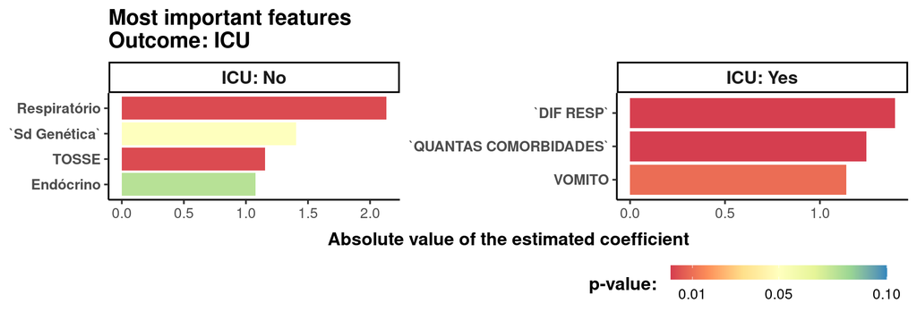

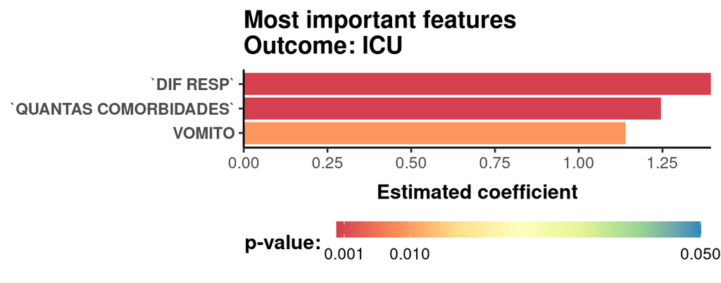

# Acurácias

> Em cada modelo, estimamos o efeito/impacto de cada característica. De tal modo, somos capazes de computar a probabilidade de desfecho para cada paciente, com base nas características contidas no modelo final. Arredondando essas probabilidades temos 0 ou 1, desfecho não ou sim.

> Abaixo temos as acurácias de cada modelo e a sua tabela de dupla entrada indicando os percentuais de acerto e erro em cada possível combinação de desfechos observado (dado) e predito (pelo modelo).

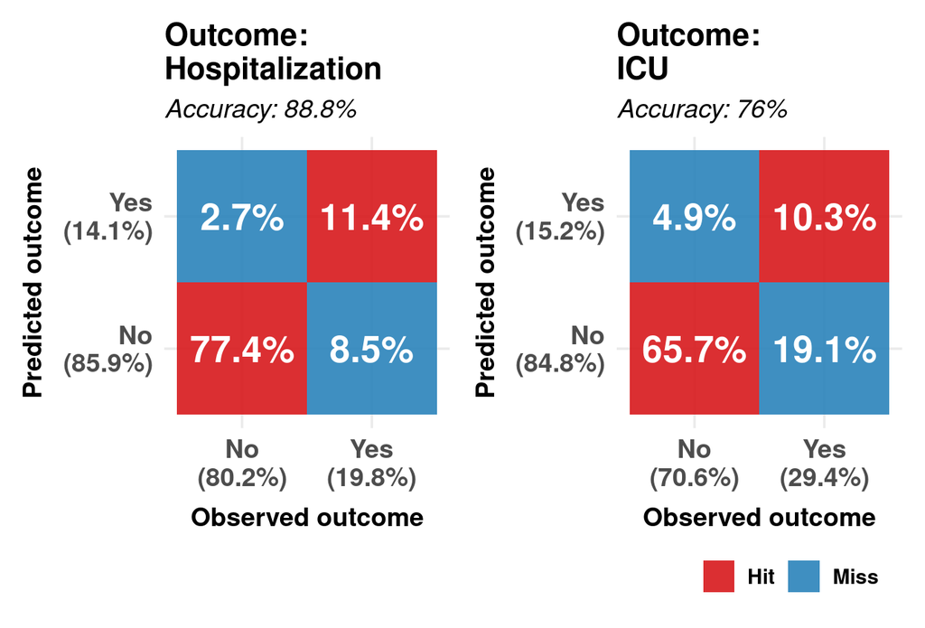

# Referências

> A análise estatística foi realizada no ambiente de computação estatística `R` (R Core Team, 2022). Os principais pacotes `R` utilizados foram o {`dplyr`} (Wickham et al., 2022), {`tidyr`} (Wickham & Girlich, 2022), {`forcats`} (Wickham, 2021), {`lubridate`} (Grolemund & Wickham, 2011), {`stringr`} (Wickham, 2019), {`purrr`} (Henry & Wickham, 2020), {`MASS`} (Venables & Ripley, 2002), {`marginaleffects`} (Arel-Bundock, 2022), {`ggplot2`} (Wickham, 2016), e {`patckwork`} (Pedersen, 2020).

> R Core Team (2022). R: A language and environment for statistical computing. R Foundation for Statistical Computing, Vienna, Austria. URL https://www.R-project.org/

> Wickham, H., François, R., Henry, L., Müller, K. (2022). dplyr: A Grammar of Data Manipulation. R package version 1.0.9. https://CRAN.R-project.org/package=dplyr

> Wickham, H., Girlich, M. (2022). tidyr: Tidy Messy Data. R package version 1.2.0, https://CRAN.R-project.org/package=tidyr

> Wickham, H. (2021). forcats: Tools for Working with Categorical Variables (Factors). R package version 0.5.1, https://CRAN.R-project.org/package=forcats

> Grolemund, G., Wickham, H. (2011). Dates and Times Made Easy with lubridate. Journal of Statistical Software, 40(3), 1-25. https://www.jstatsoft.org/v40/i03/

> Wickham, H. (2019). stringr: Simple, Consistent Wrappers for Common String Operations. R package version 1.4.0, https://CRAN.R-project.org/package=stringr

> Henry, L., Wickham, H. (2020). purrr: Functional Programming Tools. R package version 0.3.4, https://CRAN.R-project.org/package=purrr

> Venables, W. N., Ripley, B. D. (2002). Modern Applied Statistics with S. Fourth Edition. Springer, New York. ISBN 0-387-95457-0

> Arel-Bundock, V. (2022). marginaleffects: Marginal Effects, Marginal Means, Predictions, and Contrasts. R package version 0.5.0, https://CRAN.R-project.org/package=marginaleffects

> Wickham, H. (2016). ggplot2: Elegant Graphics for Data Analysis. Springer-Verlag New York

> Pedersen, T. L. (2020). patchwork: The Composer of Plots. R package version 1.1.1. https://CRAN.R-project.org/package=patchwork